# Assigment #1

Ramiro Casó - Incae Business School

6/8/2021

### Importing the data

```r
data_wide <- read_csv("data_wide.csv")
View(data_wide)
```

### Task 1 Transpose the data from wide form to long form. I also preview the first 10 rows of the new pivoted data set

```r
data_long <- data_wide %>%
  pivot_longer(cols = c(y1,y2,y3,y4,y5,x1,x2,x3,x4,x5),
   names_to = c(".value", "Group"),
   names_pattern = "(.)(.)")

head(data_long,10)
```

```
## # A tibble: 10 x 4
##       id Group      y       x
##    <dbl> <chr>  <dbl>   <dbl>
##  1     1 1     -0.855 -1.08
##  2     1 2     -2.29   1.61
##  3     1 3     -0.620 -0.181
##  4     1 4      0.376  2.61
##  5     1 5     -0.768  2.01
##  6     2 1     -0.589 -0.0690
##  7     2 2     -2.91   2.01
##  8     2 3     -1.63   2.35
##  9     2 4     -1.51   0.478
## 10     2 5     -2.22   1.13
```

### Task 2: Plot the data in aggregate and describe what you see

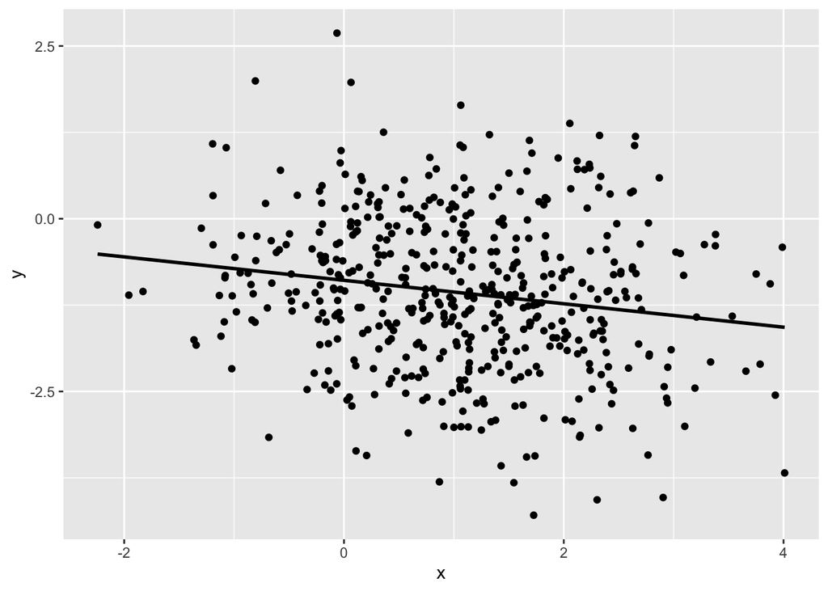

```r
ggplot(data = data_long, mapping = aes(x = x, y = y)) +
  geom_point() +
  geom_smooth(method = "lm", na.rm = T, col = "black", se = F)
```

What we can see from the data is a slightly negative relationship between x and y.

### Task 3: Plot the data by group to see if there is any evidence of Simpson’s paradox. What do you think after looking at this?

First, I’ll try to see if coloring by group allow us to see if there is any evidence of Simpson’s Paradox.

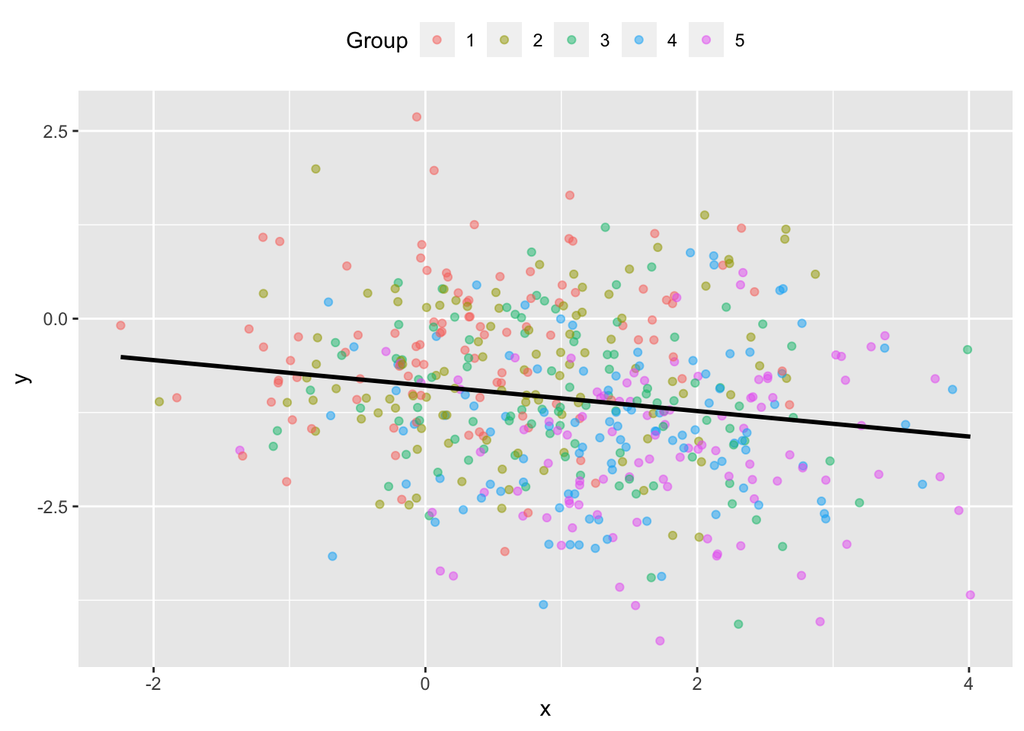

```r
ggplot(data = data_long, mapping = aes(x = x, y = y)) +
  geom_point (na.rm = T, aes(col = Group), alpha = 0.5) +
  geom_smooth(method = "lm", na.rm = T, col = "black", se = F) +
  theme(legend.position = "top")
```

Since there are so many groups, it may be better to build separece scatter plots.

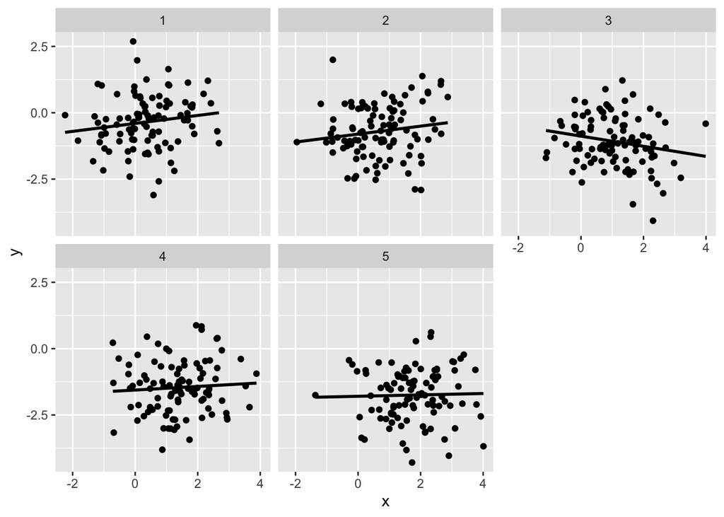

```r
ggplot(data = data_long, mapping = aes(x = x, y = y)) +
     geom_point () +
     geom_smooth(method = "lm", na.rm = T, col = "black", se = F) +
     facet_wrap(~ Group)
```

Yes, it appears to be evidence of Simpson’s Paradox, since the relationship between x and y seems slightly positive for all groups, execpt maybe for groups 3 and 5

### Task 4: Fit a pooled model ignoring the hierarchical structure of the data (using the lm function in r)

```r
pooled_model <- lm(y ~ 1 + x, data = data_long)
summary(pooled_model)
```

```
##
## Call:
## lm(formula = y ~ 1 + x, data = data_long)
##
## Residuals:
##     Min      1Q  Median      3Q     Max
## -3.1068 -0.6954 -0.0395  0.7216  3.5675
##
## Coefficients:
##             Estimate Std. Error t value Pr(>|t|)
## (Intercept) -0.89140    0.06724 -13.257  < 2e-16 ***
## x           -0.16961    0.04398  -3.857  0.00013 ***
## ---
## Signif. codes:  0 '***' 0.001 '**' 0.01 '*' 0.05 '.' 0.1 ' ' 1
##
## Residual standard error: 1.093 on 498 degrees of freedom
## Multiple R-squared:  0.029,  Adjusted R-squared:  0.02705
## F-statistic: 14.87 on 1 and 498 DF,  p-value: 0.00013
```

### Task 5: Fit a multilevel model with random intercepts for each group in the data (use the lmer function in r). What changes in the parameters between the pooled and multilevel models?

```r
# First, I need create a fit random intercepts model
intercepts_model <- lmer(y ~ 1+ x + (1 | Group), data = data_long)

# Then I extract the group's coefficients.
model_coefs_rani <- coef(intercepts_model)$Group %>%
  rename(Intercept = `(Intercept)`, Slope = x) %>%
  rownames_to_column("Group")

# and here we can see coefficients
model_coefs_rani
```

```
##   Group  Intercept      Slope
## 1     1 -0.3829645 0.03302978
## 2     2 -0.7341037 0.03302978
## 3     3 -1.1161534 0.03302978
## 4     4 -1.5000831 0.03302978
## 5     5 -1.7875212 0.03302978
```

The main difference is in the sign of the slope. As you can see, in the pooled model, the slope is negative (as seen aslo in the original scatter plot). When you create a model with random intercepts, we now have a positive single value of slopes. This is indicative of Simpson’s Paradox.

We can plot this coefficients to see the difference by joining the new intercepts and slopes to the original data set. I will create a second data set named `data_long_rani` for that.

```r
data_long_rani <- left_join(data_long, model_coefs_rani, by = "Group")
```

Once I have extracted the coefficients and joined them to my original data set, I can plot it.

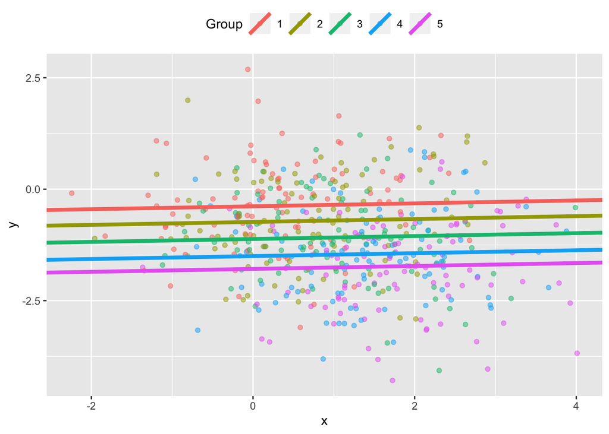

```r
model_coef_plot <- ggplot(data = data_long_rani,
       mapping = aes(x = x,
                     y = y,
                     colour = Group)
       ) +
  geom_point(na.rm = T, alpha = 0.5) +
  geom_abline(aes(intercept = Intercept,
                  slope = Slope,
                  colour = Group
                  ),
              size = 1.5
              ) +
  theme(legend.position = "top")

# see the plot
model_coef_plot
```

### Task 6: Fit a model with random intercepts and slopes for each group.

```r
# fit random slopes model
ranis_model <- lmer(y ~ x + (1 + x | Group), data = data_long)

# Then I extract the group's coefficients as before
model_coefs_ranis <- coef(ranis_model)$Group %>%
  rename(Intercept = `(Intercept)`, Slope = x) %>%
  rownames_to_column("Group")

# see coefficients
model_coefs_ranis
```

```
##   Group  Intercept       Slope
## 1     1 -0.4109366  0.11800933
## 2     2 -0.7745281  0.09830471
## 3     3 -1.0399597 -0.05148479
## 4     4 -1.4747928  0.01791304
## 5     5 -1.6987381 -0.01691433
```

Next, we’ll join these coefficients to our original data.

```r
data_long_ranis <- left_join(data_long, model_coefs_ranis, by = "Group")
```

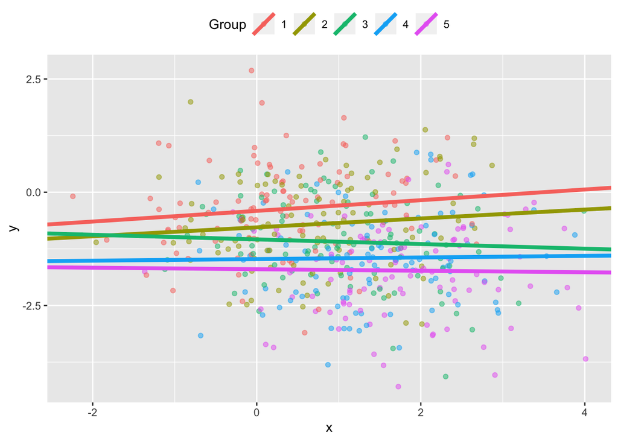

```r
model_coef_plot %+% data_long_ranis
```

### Task 7: Fit a model with crossed random effects (both intercepts and slopes) for both group and id.

```r
cross_ran_model <- lmer(y ~ 1+ x + (1 | id) + (1 | Group), data = data_long)
summary(cross_ran_model)
```

```
## Linear mixed model fit by REML ['lmerMod']
## Formula: y ~ 1 + x + (1 | id) + (1 | Group)
##    Data: data_long
##
## REML criterion at convergence: 1429.9
##
## Scaled residuals:
##     Min      1Q  Median      3Q     Max
## -3.0479 -0.6352 -0.0254  0.7043  3.0885
##
## Random effects:
##  Groups   Name        Variance Std.Dev.
##  id       (Intercept) 0.007728 0.08791
##  Group    (Intercept) 0.330299 0.57472
##  Residual             0.972625 0.98622
## Number of obs: 500, groups:  id, 100; Group, 5
##
## Fixed effects:
##             Estimate Std. Error t value
## (Intercept) -1.10400    0.26504  -4.165
## x            0.03287    0.04433   0.742
##
## Correlation of Fixed Effects:
##   (Intr)
## x -0.176
```

### Task 8: Because the models in Tasks 5, 6, and 7 are all nested, use a Chi-square test on model deviance to assess whether the more complicated models (i.e., those in Tasks 6 and 7) provide better model fits. To do this, it would be helpful to use the “anova” function in r.

```r
anova(intercepts_model, ranis_model, cross_ran_model, test = "Chisq")
```

```
## refitting model(s) with ML (instead of REML)
```

```
## Data: data_long
## Models:
## intercepts_model: y ~ 1 + x + (1 | Group)
## cross_ran_model: y ~ 1 + x + (1 | id) + (1 | Group)
## ranis_model: y ~ x + (1 + x | Group)
##                  npar    AIC    BIC  logLik deviance  Chisq Df Pr(>Chisq)
## intercepts_model    4 1432.6 1449.5 -712.31   1424.6
## cross_ran_model     5 1434.6 1455.6 -712.28   1424.6 0.0603  1     0.8060
## ranis_model         6 1435.3 1460.5 -711.63   1423.3 1.3097  1     0.2524
```